# Credit Risk Scoring & Default Prediction

### A consumer-credit default model, calibrated risk scoring, and regulator-style adverse action explanations

**Goal.** Predict the probability that a consumer-credit applicant will default, turn that probability into an interpretable credit score / risk band, and — going one step beyond a typical scoring notebook — automatically generate **ECOA/Reg B–style "adverse action" reason codes** for declined applicants, the way a real lender is legally required to.

**Dataset.** A classic consumer credit-scoring dataset (4,455 loan applicants, gastonstat/CreditScoring, based on a data-mining course dataset widely used in credit-risk teaching material). Each row is one loan application with applicant financials (income, assets, debt, employment tenure, etc.) and the outcome (`good` / `bad` repayment).

**Contents**

1. Load & inspect data
2. Exploratory data analysis
3. Missing value treatment
4. Feature engineering
5. Train / test split & preprocessing
6. Baseline model — Logistic Regression
7. XGBoost
8. Model evaluation (ROC-AUC, PR-AUC, confusion matrix)
9. Probability calibration
10. Feature importance (SHAP)
11. Credit score & risk-band framework
12. **Extension — Adverse Action Reason Codes**
13. Conclusion & next steps

```python
import warnings
warnings.filterwarnings("ignore")

import numpy as np
import pandas as pd
import matplotlib.pyplot as plt
import seaborn as sns
%matplotlib inline

from sklearn.model_selection import train_test_split
from sklearn.linear_model import LogisticRegression
from sklearn.preprocessing import StandardScaler, OneHotEncoder
from sklearn.impute import SimpleImputer
from sklearn.compose import ColumnTransformer
from sklearn.pipeline import Pipeline
from sklearn.calibration import CalibratedClassifierCV, calibration_curve
from sklearn.metrics import (roc_auc_score, average_precision_score, brier_score_loss,
                              roc_curve, precision_recall_curve, confusion_matrix,
                              ConfusionMatrixDisplay, classification_report)
import xgboost as xgb
import shap

pd.set_option("display.max_columns", 50)
sns.set_style("whitegrid")
plt.rcParams["figure.figsize"] = (7, 4.5)
RANDOM_STATE = 42
np.random.seed(RANDOM_STATE)
```

## 1. Load & inspect data

```python
df = pd.read_csv("CreditScoring_raw.csv")
df.columns = [c.lower() for c in df.columns]
print(f"Shape: {df.shape}")
df.head()
```

```
Shape: (4455, 14)
```

|  | status | seniority | home | time | age | marital | records | job | expenses | income | assets | debt | amount | price |
| --- | --- | --- | --- | --- | --- | --- | --- | --- | --- | --- | --- | --- | --- | --- |
| 0 | 1 | 9 | 1 | 60 | 30 | 2 | 1 | 3 | 73 | 129 | 0 | 0 | 800 | 846 |
| 1 | 1 | 17 | 1 | 60 | 58 | 3 | 1 | 1 | 48 | 131 | 0 | 0 | 1000 | 1658 |
| 2 | 2 | 10 | 2 | 36 | 46 | 2 | 2 | 3 | 90 | 200 | 3000 | 0 | 2000 | 2985 |
| 3 | 1 | 0 | 1 | 60 | 24 | 1 | 1 | 1 | 63 | 182 | 2500 | 0 | 900 | 1325 |
| 4 | 1 | 0 | 1 | 36 | 26 | 1 | 1 | 1 | 46 | 107 | 0 | 0 | 310 | 910 |

**Data dictionary**

| Column | Meaning |
| --- | --- |
| `status` | target: 1 = good (repaid), 2 = bad (default), 0 = unlabeled (dropped) |
| `seniority` | job seniority, years |
| `home` | type of home ownership (categorical code) |
| `time` | requested loan term, months |
| `age` | applicant age |
| `marital` | marital status (categorical code) |
| `records` | 1 = no derogatory record, 2 = has derogatory record |
| `job` | employment type (categorical code) |
| `expenses`, `income`, `assets`, `debt` | monthly amounts (local currency units) |
| `amount` | requested loan amount |
| `price` | price of the financed good |

```python
df["status"].value_counts()
```

```
status
1    3200
2    1254
0       1
Name: count, dtype: int64
```

## 2. Exploratory data analysis

First, the target. Consumer-credit portfolios are usually imbalanced — most applicants repay — and this one is no exception, so accuracy alone would be a misleading metric (predicting "everyone is good" gets ~72% accuracy for free). That's exactly why the brief calls for ROC-AUC / PR-AUC instead.

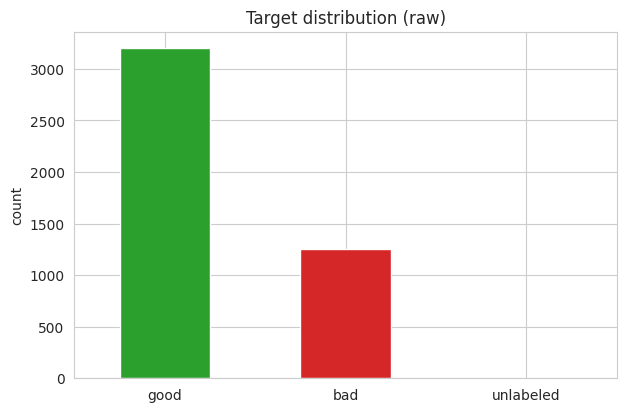

```python
fig, ax = plt.subplots()
df["status"].map({1: "good", 2: "bad", 0: "unlabeled"}).value_counts().plot(
    kind="bar", ax=ax, color=["#2ca02c", "#d62728", "#7f7f7f"]
)
ax.set_title("Target distribution (raw)")
ax.set_xlabel("")
ax.set_ylabel("count")
plt.xticks(rotation=0)
plt.show()
```

```python
df.describe().T
```

|  | count | mean | std | min | 25% | 50% | 75% | max |
| --- | --- | --- | --- | --- | --- | --- | --- | --- |
| status | 4455.0 | 1.281257e+00 | 4.501621e-01 | 0.0 | 1.0 | 1.0 | 2.0 | 2.0 |
| seniority | 4455.0 | 7.987205e+00 | 8.173444e+00 | 0.0 | 2.0 | 5.0 | 12.0 | 48.0 |
| home | 4455.0 | 2.657015e+00 | 1.610467e+00 | 0.0 | 2.0 | 2.0 | 4.0 | 6.0 |
| time | 4455.0 | 4.644175e+01 | 1.465523e+01 | 6.0 | 36.0 | 48.0 | 60.0 | 72.0 |
| age | 4455.0 | 3.707767e+01 | 1.098486e+01 | 18.0 | 28.0 | 36.0 | 45.0 | 68.0 |
| marital | 4455.0 | 1.879012e+00 | 6.437478e-01 | 0.0 | 2.0 | 2.0 | 2.0 | 5.0 |
| records | 4455.0 | 1.173513e+00 | 3.787326e-01 | 1.0 | 1.0 | 1.0 | 1.0 | 2.0 |
| job | 4455.0 | 1.675870e+00 | 9.540352e-01 | 0.0 | 1.0 | 1.0 | 3.0 | 4.0 |
| expenses | 4455.0 | 5.556880e+01 | 1.951588e+01 | 35.0 | 35.0 | 51.0 | 72.0 | 180.0 |
| income | 4455.0 | 7.633170e+05 | 8.703625e+06 | 0.0 | 80.0 | 120.0 | 166.0 | 99999999.0 |
| assets | 4455.0 | 1.060341e+06 | 1.021757e+07 | 0.0 | 0.0 | 3500.0 | 6000.0 | 99999999.0 |
| debt | 4455.0 | 4.043820e+05 | 6.344253e+06 | 0.0 | 0.0 | 0.0 | 0.0 | 99999999.0 |
| amount | 4455.0 | 1.039022e+03 | 4.745430e+02 | 100.0 | 700.0 | 1000.0 | 1300.0 | 5000.0 |
| price | 4455.0 | 1.462876e+03 | 6.280899e+02 | 105.0 | 1117.5 | 1400.0 | 1692.0 | 11140.0 |

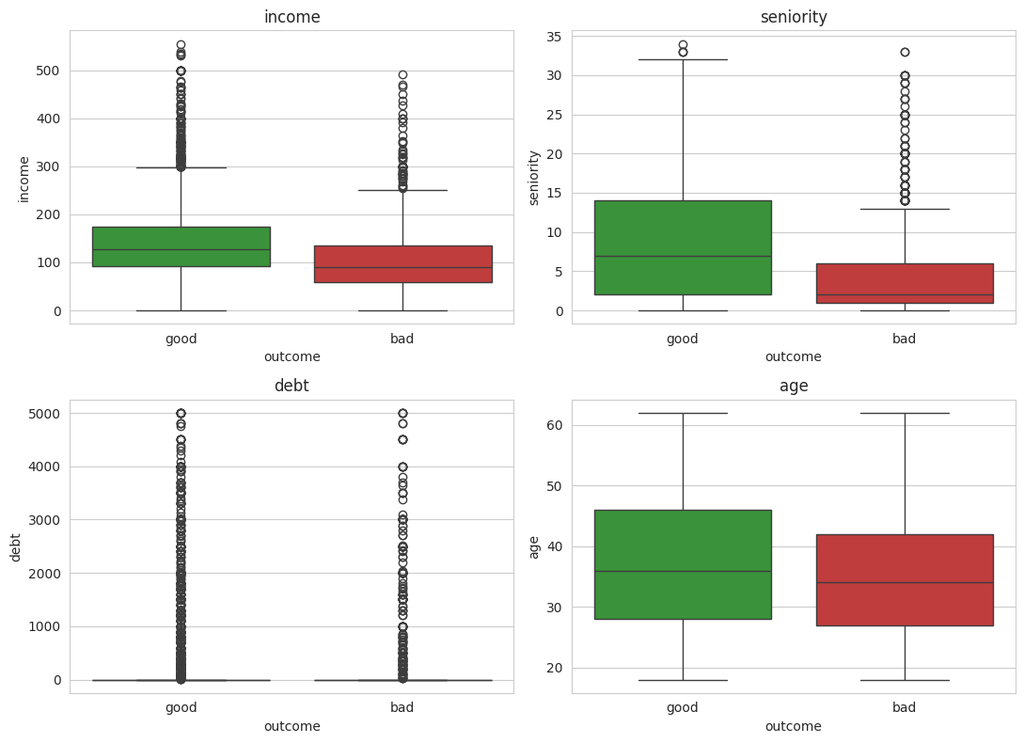

```python
# quick look at how a few key numeric fields differ between eventual good vs bad payers
plot_df = df[df["status"] != 0].copy()
plot_df["outcome"] = plot_df["status"].map({1: "good", 2: "bad"})

fig, axes = plt.subplots(2, 2, figsize=(11, 8))
for ax, col in zip(axes.ravel(), ["income", "seniority", "debt", "age"]):
    sns.boxplot(data=plot_df[plot_df[col] < plot_df[col].quantile(0.99)],
                x="outcome", y=col, ax=ax, palette=["#2ca02c", "#d62728"])
    ax.set_title(col)
plt.tight_layout()
plt.show()
```

## 3. Missing value treatment

This dataset encodes missing data two different ways, which is worth catching before it silently corrupts a model:

- **Numeric sentinel:** `income`, `assets`, `debt` use `99999999` to mean "not reported". Left as-is, a model would read that as an implausibly high income — exactly backwards.
- **Categorical sentinel:** `home`, `marital`, `job` use `0` to mean "unknown".

Treatment: convert both sentinels to real `NaN`, add **missingness indicator flags** for the numeric fields (whether income was missing can itself be predictive — e.g. self-employed applicants under-report income), then median/mode-impute inside the modelling pipeline (fit on train only).

```python
SENTINEL = 99999999
num_sentinel_cols = ["income", "assets", "debt"]
cat_unknown_cols = ["home", "marital", "job"]

df = df[df["status"] != 0].copy()                       # drop the single unlabeled row
df["default"] = (df["status"] == 2).astype(int)         # 1 = bad/default, 0 = good
df.drop(columns=["status"], inplace=True)

missing_report = {}
for c in num_sentinel_cols:
    missing_report[c] = int((df[c] == SENTINEL).sum())
    df[c] = df[c].replace(SENTINEL, np.nan)
for c in cat_unknown_cols:
    missing_report[c] = int((df[c] == 0).sum())
    df[c] = df[c].replace(0, np.nan)

print("Missing values found per column:")
for k, v in missing_report.items():
    print(f"  {k:10s}: {v}")

for c in num_sentinel_cols:
    df[c + "_was_missing"] = df[c].isna().astype(int)
```

```
Missing values found per column:
  income    : 34
  assets    : 47
  debt      : 18
  home      : 6
  marital   : 1
  job       : 2
```

## 4. Feature engineering

```python
df["records"] = df["records"].map({1: 0, 2: 1})   # 1 = has derogatory record
eps = 1.0
df["debt_to_income"]        = df["debt"]   / (df["income"] + eps)
df["loan_to_income"]        = df["amount"] / (df["income"] + eps)
df["installment"]           = df["amount"] / df["time"].replace(0, np.nan)
df["installment_to_income"] = df["installment"] / (df["income"] + eps)
df["finance_ratio"]         = df["amount"] / df["price"].replace(0, np.nan)   # % of price financed

target = "default"
num_features  = ["seniority", "time", "age", "expenses", "income", "assets", "debt",
                  "amount", "price", "debt_to_income", "loan_to_income",
                  "installment_to_income", "finance_ratio"]
cat_features  = ["home", "marital", "job"]
bin_features  = ["records", "income_was_missing", "assets_was_missing", "debt_was_missing"]
RATIO_COLS    = ["debt_to_income", "loan_to_income", "installment_to_income"]

X = df[num_features + cat_features + bin_features].copy()
y = df[target].copy()
print(X.shape, "| default rate:", round(y.mean(), 3))
```

```
(4454, 20) | default rate: 0.282
```

## 5. Train / test split & preprocessing

A 75/25 stratified split keeps the ~28% default rate consistent in both sets. The three engineered ratio features get **winsorized at the 99th percentile** — a handful of near-zero-income applicants otherwise produce absurd ratios (debt-to-income in the thousands) that would dominate a linear model. Caps are learned on the **training set only** and applied to test, to avoid leakage.

```python
X_train, X_test, y_train, y_test = train_test_split(
    X, y, test_size=0.25, stratify=y, random_state=RANDOM_STATE
)

for c in RATIO_COLS:
    cap = X_train[c].quantile(0.99)
    X_train[c] = X_train[c].clip(upper=cap)
    X_test[c]  = X_test[c].clip(upper=cap)

print("Train:", X_train.shape, " Test:", X_test.shape)
```

```
Train: (3340, 20)  Test: (1114, 20)
```

## 6. Baseline model — Logistic Regression

The interpretable baseline. Numeric features are median-imputed and scaled; categoricals are one-hot encoded. `class_weight="balanced"` compensates for the ~28% default rate instead of letting the model default to predicting "good" for everyone.

```python
numeric_transform = Pipeline([
    ("impute", SimpleImputer(strategy="median")),
    ("scale", StandardScaler()),
])
cat_transform_ohe = Pipeline([
    ("impute", SimpleImputer(strategy="most_frequent")),
    ("ohe", OneHotEncoder(handle_unknown="ignore")),
])
preprocess_logit = ColumnTransformer([
    ("num", numeric_transform, num_features),
    ("cat", cat_transform_ohe, cat_features),
    ("bin", "passthrough", bin_features),
])

logit_pipe = Pipeline([
    ("prep", preprocess_logit),
    ("clf", LogisticRegression(max_iter=2000, class_weight="balanced", random_state=RANDOM_STATE)),
])
logit_pipe.fit(X_train, y_train)
logit_proba = logit_pipe.predict_proba(X_test)[:, 1]

print(f"Logistic Regression  ROC-AUC: {roc_auc_score(y_test, logit_proba):.4f}"
      f"   PR-AUC: {average_precision_score(y_test, logit_proba):.4f}")
```

```
Logistic Regression  ROC-AUC: 0.8455   PR-AUC: 0.7035
```

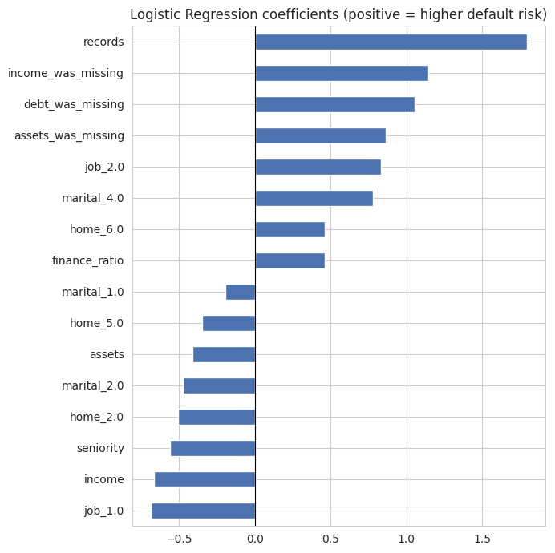

```python
# interpretability: which features push risk up / down?
ohe_names = logit_pipe.named_steps["prep"].named_transformers_["cat"].named_steps["ohe"].get_feature_names_out(cat_features)
all_names = num_features + list(ohe_names) + bin_features
coefs = pd.Series(logit_pipe.named_steps["clf"].coef_[0], index=all_names).sort_values()

fig, ax = plt.subplots(figsize=(7, 7))
pd.concat([coefs.head(8), coefs.tail(8)]).plot(kind="barh", ax=ax, color="#4C72B0")
ax.set_title("Logistic Regression coefficients (positive = higher default risk)")
ax.axvline(0, color="black", linewidth=0.8)
plt.tight_layout()
plt.show()
```

## 7. XGBoost

A gradient-boosted tree model to capture non-linearities and interactions the logistic baseline can't (e.g. the effect of debt-to-income may depend on employment tenure). `scale_pos_weight` handles the class imbalance the way `class_weight="balanced"` did for logistic regression.

```python
xgb_prep = ColumnTransformer([
    ("num", SimpleImputer(strategy="median"), num_features),
    ("cat", SimpleImputer(strategy="most_frequent"), cat_features),
    ("bin", "passthrough", bin_features),
])
Xtr_xgb = xgb_prep.fit_transform(X_train, y_train)
Xte_xgb = xgb_prep.transform(X_test)
feat_names_xgb = num_features + cat_features + bin_features

scale_pos_weight = (y_train == 0).sum() / (y_train == 1).sum()
xgb_clf = xgb.XGBClassifier(
    n_estimators=300, max_depth=4, learning_rate=0.05,
    subsample=0.9, colsample_bytree=0.9, reg_lambda=1.0,
    scale_pos_weight=scale_pos_weight, eval_metric="auc",
    random_state=RANDOM_STATE, n_jobs=-1,
)
xgb_clf.fit(Xtr_xgb, y_train)
xgb_proba = xgb_clf.predict_proba(Xte_xgb)[:, 1]

print(f"XGBoost               ROC-AUC: {roc_auc_score(y_test, xgb_proba):.4f}"
      f"   PR-AUC: {average_precision_score(y_test, xgb_proba):.4f}")
```

```
XGBoost               ROC-AUC: 0.8450   PR-AUC: 0.6962
```

## 8. Model evaluation

ROC-AUC and PR-AUC side by side, plus a confusion matrix at a chosen operating threshold. PR-AUC matters more here than in a balanced problem — it's much more sensitive to how well the model finds the minority "bad" class, which is what actually drives lending losses.

```python
results = pd.DataFrame({
    "model": ["Logistic Regression", "XGBoost"],
    "roc_auc": [roc_auc_score(y_test, logit_proba), roc_auc_score(y_test, xgb_proba)],
    "pr_auc":  [average_precision_score(y_test, logit_proba), average_precision_score(y_test, xgb_proba)],
})
results
```

|  | model | roc_auc | pr_auc |
| --- | --- | --- | --- |
| 0 | Logistic Regression | 0.845486 | 0.703503 |
| 1 | XGBoost | 0.845044 | 0.696203 |

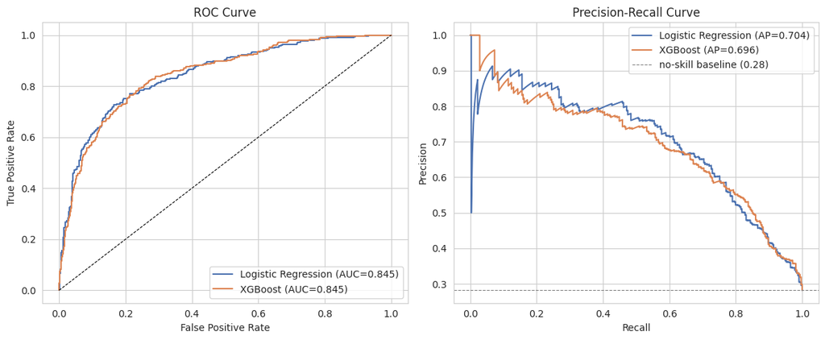

```python
fig, axes = plt.subplots(1, 2, figsize=(12, 5))

for proba, label, color in [(logit_proba, "Logistic Regression", "#4C72B0"), (xgb_proba, "XGBoost", "#DD8452")]:
    fpr, tpr, _ = roc_curve(y_test, proba)
    axes[0].plot(fpr, tpr, label=f"{label} (AUC={roc_auc_score(y_test, proba):.3f})", color=color)
    prec, rec, _ = precision_recall_curve(y_test, proba)
    axes[1].plot(rec, prec, label=f"{label} (AP={average_precision_score(y_test, proba):.3f})", color=color)

axes[0].plot([0, 1], [0, 1], "k--", linewidth=0.8)
axes[0].set_xlabel("False Positive Rate"); axes[0].set_ylabel("True Positive Rate"); axes[0].set_title("ROC Curve")
axes[0].legend()

baseline = y_test.mean()
axes[1].axhline(baseline, color="gray", linestyle="--", linewidth=0.8, label=f"no-skill baseline ({baseline:.2f})")
axes[1].set_xlabel("Recall"); axes[1].set_ylabel("Precision"); axes[1].set_title("Precision-Recall Curve")
axes[1].legend()
plt.tight_layout()
plt.show()
```

```
              precision    recall  f1-score   support

        good       0.88      0.80      0.84       800
         bad       0.59      0.73      0.65       314

    accuracy                           0.78      1114
   macro avg       0.74      0.76      0.74      1114
weighted avg       0.80      0.78      0.79      1114
```

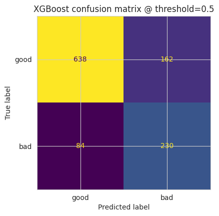

```python
threshold = 0.5
y_pred = (xgb_proba >= threshold).astype(int)
print(classification_report(y_test, y_pred, target_names=["good", "bad"]))

fig, ax = plt.subplots(figsize=(4.5, 4.5))
ConfusionMatrixDisplay.from_predictions(y_test, y_pred, display_labels=["good", "bad"], ax=ax, colorbar=False)
ax.set_title(f"XGBoost confusion matrix @ threshold={threshold}")
plt.show()
```

## 9. Probability calibration

Raw XGBoost probabilities are typically **not** well calibrated — a "0.7" from the model doesn't necessarily mean a true 70% default rate, which matters a lot here because the whole point of the next section is to translate probabilities directly into a score. Isotonic calibration (5-fold, out-of-fold) is used and validated with the **Brier score** — the standard metric for how well predicted probabilities match observed outcomes (lower is better) — and a reliability curve.

```python
print(f"Brier score, uncalibrated XGBoost: {brier_score_loss(y_test, xgb_proba):.4f}")

xgb_for_calib = xgb.XGBClassifier(
    n_estimators=300, max_depth=4, learning_rate=0.05,
    subsample=0.9, colsample_bytree=0.9, reg_lambda=1.0,
    scale_pos_weight=scale_pos_weight, eval_metric="auc",
    random_state=RANDOM_STATE, n_jobs=-1,
)
calib = CalibratedClassifierCV(xgb_for_calib, method="isotonic", cv=5)
calib.fit(Xtr_xgb, y_train)
calib_proba = calib.predict_proba(Xte_xgb)[:, 1]

print(f"Brier score, calibrated XGBoost:   {brier_score_loss(y_test, calib_proba):.4f}")
print(f"ROC-AUC is rank-based so it barely moves with calibration: {roc_auc_score(y_test, calib_proba):.4f}")
```

```
Brier score, uncalibrated XGBoost: 0.1518
```

```
Brier score, calibrated XGBoost:   0.1372
ROC-AUC is rank-based so it barely moves with calibration: 0.8438
```

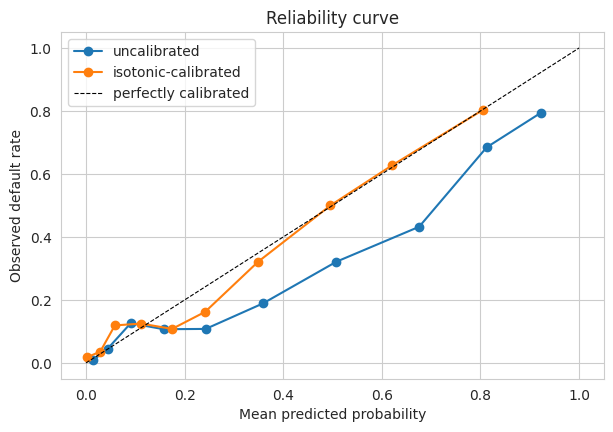

```python
fig, ax = plt.subplots()
for proba, label in [(xgb_proba, "uncalibrated"), (calib_proba, "isotonic-calibrated")]:
    frac_pos, mean_pred = calibration_curve(y_test, proba, n_bins=10, strategy="quantile")
    ax.plot(mean_pred, frac_pos, marker="o", label=label)
ax.plot([0, 1], [0, 1], "k--", linewidth=0.8, label="perfectly calibrated")
ax.set_xlabel("Mean predicted probability"); ax.set_ylabel("Observed default rate"); ax.set_title("Reliability curve")
ax.legend()
plt.show()
```

## 10. Feature importance — SHAP

Global feature importance from SHAP values on the (uncalibrated-structure) XGBoost model. This isn't just for the plot below — the **same per-applicant SHAP values power the adverse-action reason codes in Section 12**.

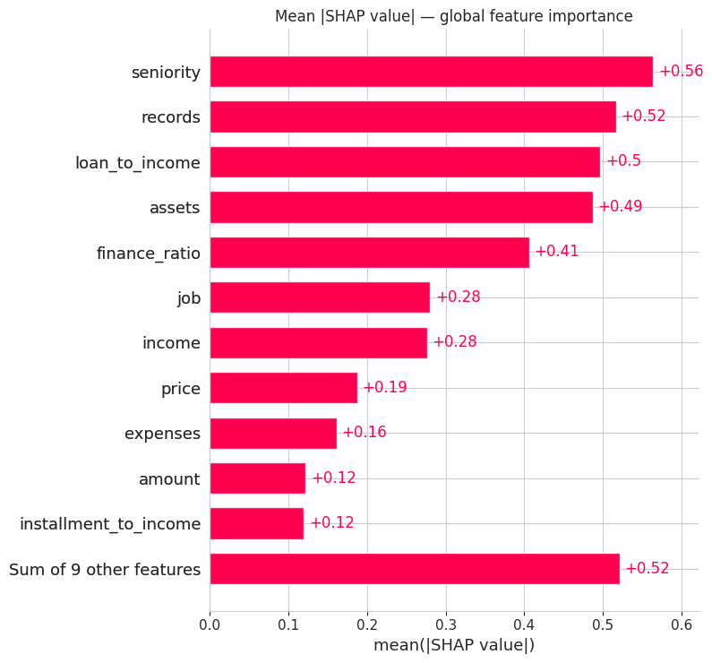

```python
explainer = shap.TreeExplainer(xgb_clf)
sv = explainer(pd.DataFrame(Xte_xgb, columns=feat_names_xgb))

shap.plots.bar(sv, max_display=12, show=False)
plt.title("Mean |SHAP value| — global feature importance")
plt.tight_layout()
plt.show()
```

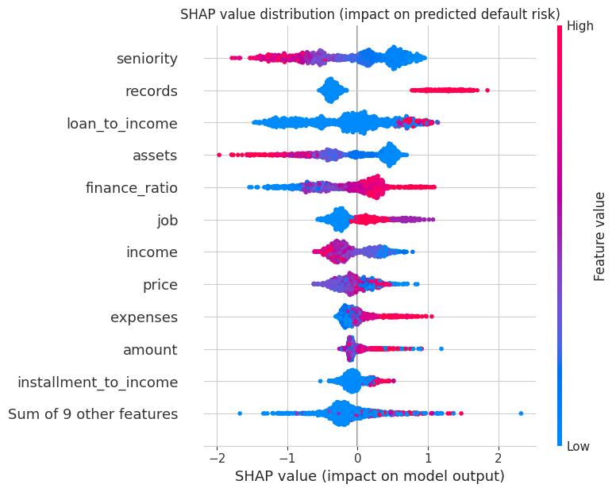

```python
shap.plots.beeswarm(sv, max_display=12, show=False)
plt.title("SHAP value distribution (impact on predicted default risk)")
plt.tight_layout()
plt.show()
```

## 11. Credit score & risk-band framework

Calibrated probabilities are converted to a familiar 3-digit score using the same log-odds (PDO) formula real bureaus use:

$$\text{score} = \text{offset} + \text{factor} \times \ln(\text{odds of good})$$

**Design choice:** the formula is anchored to *this portfolio's own* average odds (≈28% default rate) rather than borrowing a generic prime-book constant like "50:1 good:bad at 600" — that constant assumes a much safer population than this one and would push almost everyone into the bottom band, which is a common mistake in tutorial versions of this technique.

Risk bands are then cut by **score quantile** (5 equal-sized groups) and validated against the *actual* observed default rate in each group — a set of bands is only useful if real-world risk actually increases monotonically band to band.

```python
avg_bad_rate = y_train.mean()
base_odds = (1 - avg_bad_rate) / avg_bad_rate
BASE_SCORE, PDO = 650, 50
factor = PDO / np.log(2)
offset = BASE_SCORE - factor * np.log(base_odds)

p_bad = np.clip(calib_proba, 1e-6, 1 - 1e-6)
odds_good = (1 - p_bad) / p_bad
score = offset + factor * np.log(odds_good)
score = np.clip(score, 300, 850)   # cosmetic clip to a familiar 300-850 scale

score_series = pd.Series(score, index=y_test.index, name="credit_score")
score_series.describe()
```

```
count    1114.000000
mean      678.016265
std       121.615723
min       318.114802
25%       584.454085
50%       680.622462
75%       785.803928
max       850.000000
Name: credit_score, dtype: float64
```

```python
band_labels = ["E - Decline", "D - High Risk", "C - Subprime", "B - Near-Prime", "A - Prime"]
bands = pd.qcut(score_series, q=5, labels=band_labels)

validation = pd.DataFrame({"band": bands, "actual_default": y_test}).groupby("band", observed=True).agg(
    avg_score=("actual_default", "size"),   # placeholder, replaced below
    n_applicants=("actual_default", "size"),
    observed_default_rate=("actual_default", "mean"),
)
validation["avg_score"] = score_series.groupby(bands, observed=True).mean()
validation = validation[["n_applicants", "avg_score", "observed_default_rate"]]
validation
```

| band | n_applicants | avg_score | observed_default_rate |
| --- | --- | --- | --- |
| E - Decline | 225 | 505.882101 | 0.720000 |
| D - High Risk | 221 | 606.178589 | 0.402715 |
| C - Subprime | 222 | 679.973120 | 0.135135 |
| B - Near-Prime | 224 | 758.253169 | 0.120536 |
| A - Prime | 222 | 841.074033 | 0.027027 |

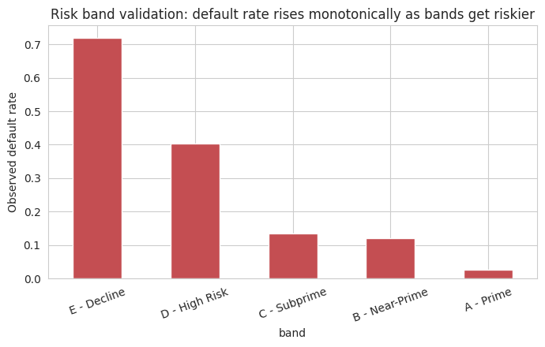

```python
fig, ax = plt.subplots()
validation["observed_default_rate"].plot(kind="bar", ax=ax, color="#C44E52")
ax.set_ylabel("Observed default rate")
ax.set_title("Risk band validation: default rate rises monotonically as bands get riskier")
plt.xticks(rotation=20)
plt.tight_layout()
plt.show()
```

## 12. Extension — Adverse Action Reason Codes (regulatory-style explainability)

**Why this matters.** In the US, the Equal Credit Opportunity Act (ECOA) and Regulation B require lenders who deny credit to give applicants **specific, principal reasons** for the denial — not just "declined." In practice this is usually implemented as the top 2–4 factors that most hurt the applicant's score, sourced from the underwriting model. Most portfolio credit-scoring projects stop at a global SHAP importance plot; this section turns those same SHAP values into **per-applicant, compliance-styled reason codes**, which is closer to what a real credit-risk or MLE team actually has to ship.

**A deliberate design decision:** the model itself can see `age`, `marital`, and `home` (residential type), and they do carry predictive signal — but they are **excluded from the customer-facing reason-code vocabulary below.** Marital status is an explicitly protected class under ECOA; age is tightly regulated; residential type can proxy geography and, historically, protected characteristics (redlining). A reason code is a compliance artifact, not just a model explanation, so it's restricted to defensible ability-to-repay factors only.

```python
ALLOWED_REASON_FEATURES = {
    "seniority":              "Limited length of employment / job tenure",
    "income":                 "Insufficient income relative to obligations",
    "assets":                 "Limited asset reserves / collateral",
    "debt":                   "High level of existing debt",
    "debt_to_income":         "High ratio of total debt to income",
    "loan_to_income":         "Requested loan amount high relative to income",
    "installment_to_income":  "Monthly installment high relative to income",
    "finance_ratio":          "High proportion of purchase price being financed",
    "records":                "History of delinquent credit obligations",
    "expenses":               "High level of recurring expenses",
    "amount":                 "Requested loan amount",
    "time":                   "Requested repayment term",
    "job":                    "Employment category / stability",
}

EXCLUDED_NOTE = (
    "Excluded from customer-facing reasons (kept in the model, never shown as a 'reason for denial'): "
    "age, marital, home, and the internal *_was_missing flags."
)
print(EXCLUDED_NOTE)

def adverse_action_reasons(row_shap, feature_names, top_n=4):
    """Top-N allowed factors pushing THIS applicant's predicted risk up, as ECOA-style reason strings."""
    pairs = [(f, v) for f, v in zip(feature_names, row_shap) if f in ALLOWED_REASON_FEATURES]
    pairs.sort(key=lambda x: x[1], reverse=True)          # positive SHAP -> pushes toward default
    return [ALLOWED_REASON_FEATURES[f] for f, v in pairs[:top_n] if v > 0]
```

```
Excluded from customer-facing reasons (kept in the model, never shown as a 'reason for denial'): age, marital, home, and the internal *_was_missing flags.
```

```python
# apply the score/band decision to every test applicant, then generate reason codes for every DECLINE
decision_df = pd.DataFrame({
    "credit_score": score_series.values,
    "band": bands.values,
    "true_default": y_test.values,
}, index=y_test.index)

declined_mask = decision_df["band"].isin(["E - Decline", "D - High Risk"]).values
declined_positions = np.where(declined_mask)[0]
print(f"{declined_mask.sum()} of {len(decision_df)} test applicants fall in a decline-tier band.")

reason_lists = [None] * len(decision_df)
for pos in declined_positions:
    reason_lists[pos] = adverse_action_reasons(sv.values[pos], feat_names_xgb, top_n=4)
decision_df["adverse_action_reasons"] = reason_lists
```

```
446 of 1114 test applicants fall in a decline-tier band.
```

```python
# sample adverse-action notice for one declined applicant
sample_pos = declined_positions[0]
sample = decision_df.iloc[sample_pos]

print("=" * 60)
print(" SAMPLE ADVERSE ACTION NOTICE (auto-generated, for demo)")
print("=" * 60)
print(f"Credit score:  {sample['credit_score']:.0f}   Risk band: {sample['band']}")
print("Principal reason(s) for this decision:")
for i, r in enumerate(sample["adverse_action_reasons"], 1):
    print(f"  {i}. {r}")
```

```
============================================================
 SAMPLE ADVERSE ACTION NOTICE (auto-generated, for demo)
============================================================
Credit score:  553   Risk band: E - Decline
Principal reason(s) for this decision:
  1. Requested loan amount high relative to income
  2. Limited asset reserves / collateral
  3. Insufficient income relative to obligations
  4. High proportion of purchase price being financed
```

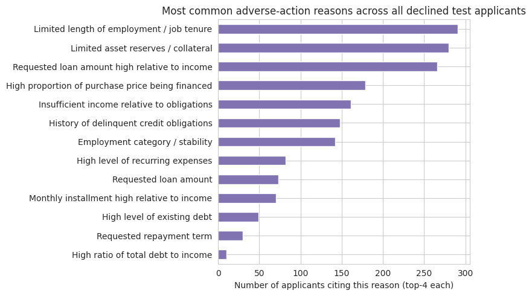

```python
# portfolio-level view: which reasons show up most often across ALL declines?
from collections import Counter
reason_counter = Counter()
for r_list in decision_df.loc[declined_mask, "adverse_action_reasons"]:
    reason_counter.update(r_list)

reason_freq = pd.Series(reason_counter).sort_values(ascending=True)
fig, ax = plt.subplots(figsize=(8, 5))
reason_freq.plot(kind="barh", ax=ax, color="#8172B2")
ax.set_title("Most common adverse-action reasons across all declined test applicants")
ax.set_xlabel("Number of applicants citing this reason (top-4 each)")
plt.tight_layout()
plt.show()
```

## 13. Conclusion & next steps

**If this went to production, the next steps would be:**

- **Reject inference** — the model is only trained on applicants who were actually funded; true population default rates for rejected applicants are unobserved and would bias the score over time.
- **Fair-lending / disparate-impact testing** — even with protected features excluded from reason codes, the *underlying model's decisions* should be tested for disparate impact across protected groups before deployment.
- **Population Stability Index (PSI) monitoring** — track whether the incoming applicant population is drifting away from the population the model was trained on.
- **Champion/challenger threshold tuning** — pick the score cutoff using the lender's actual cost of a missed default vs. cost of a lost good customer, not a fixed 0.5 threshold.